# Swing Trader · Control Centre

## A2Indicatorsfeatures, macd, averages, fibonacci, confluence

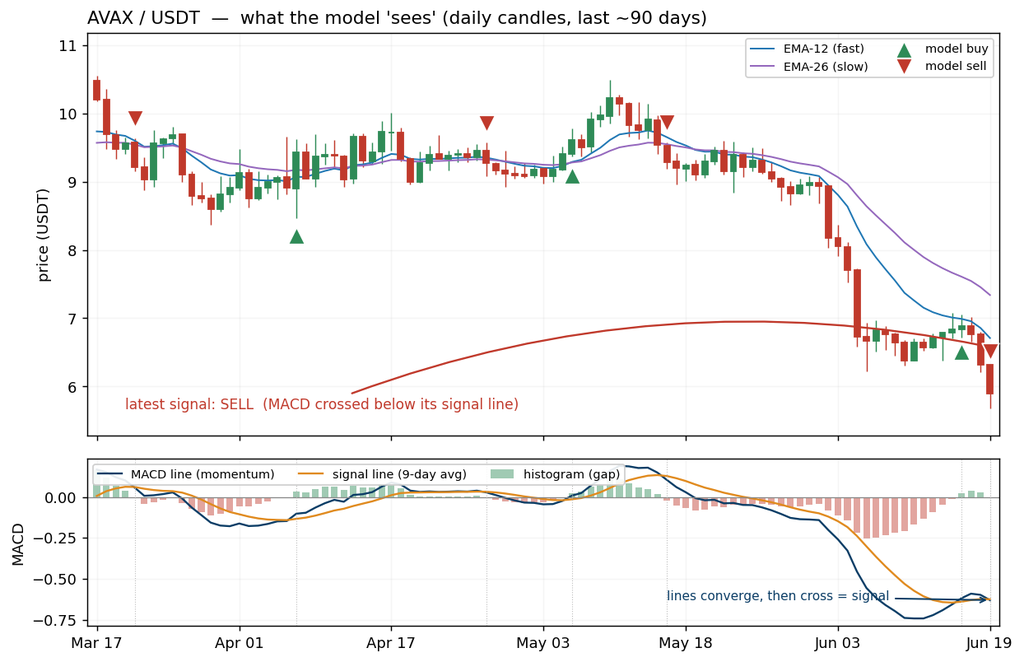

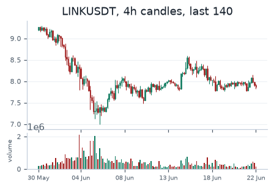

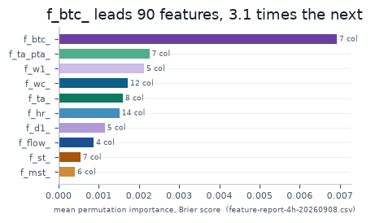

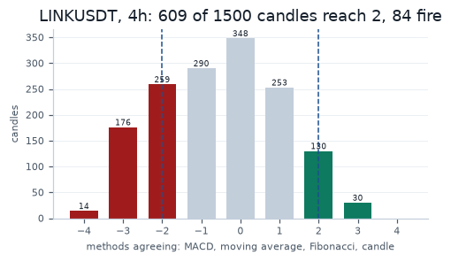

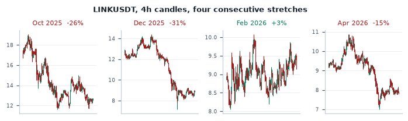

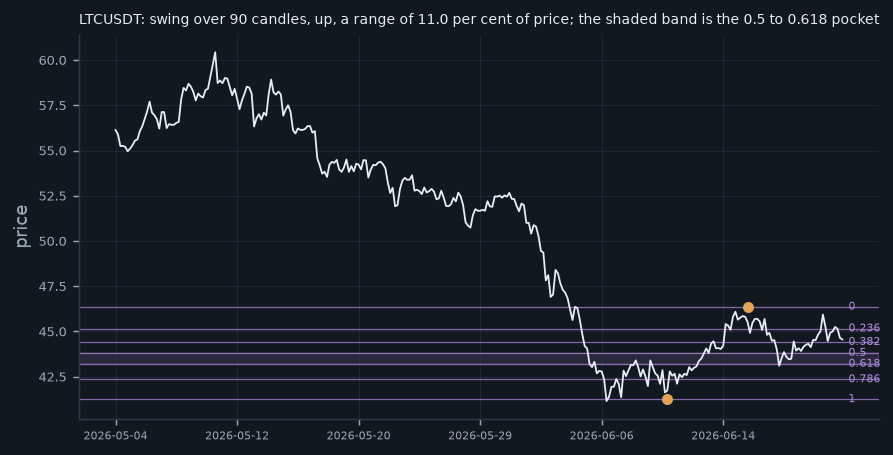

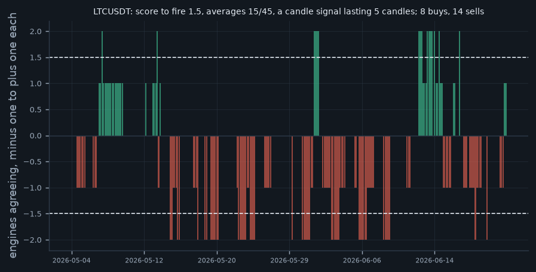

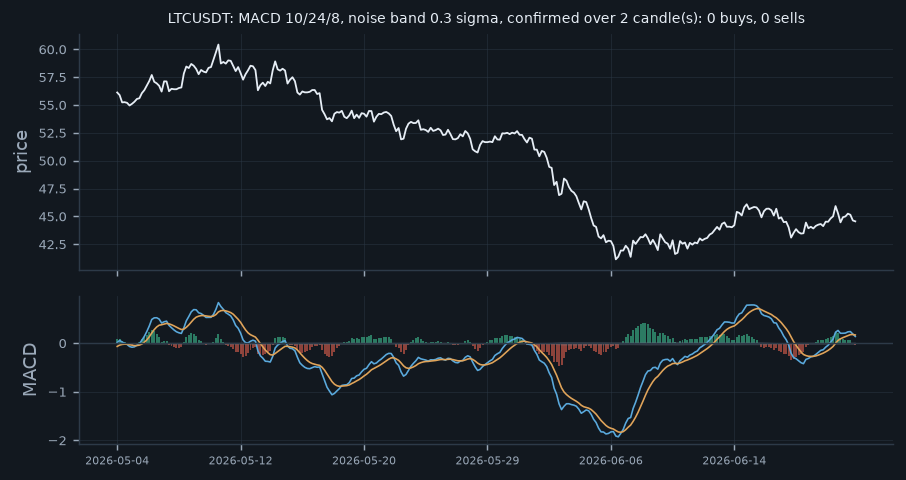

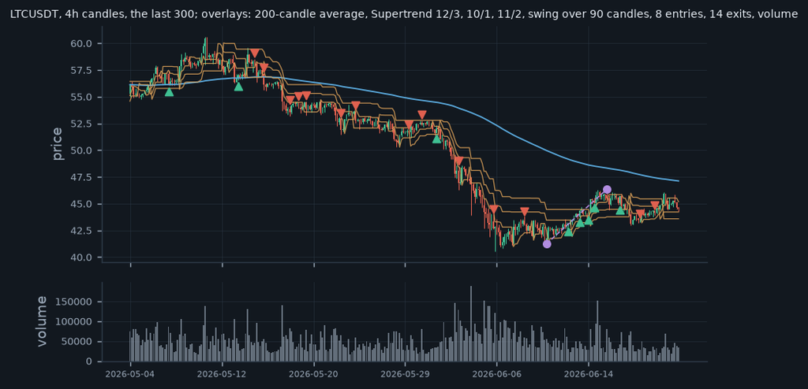

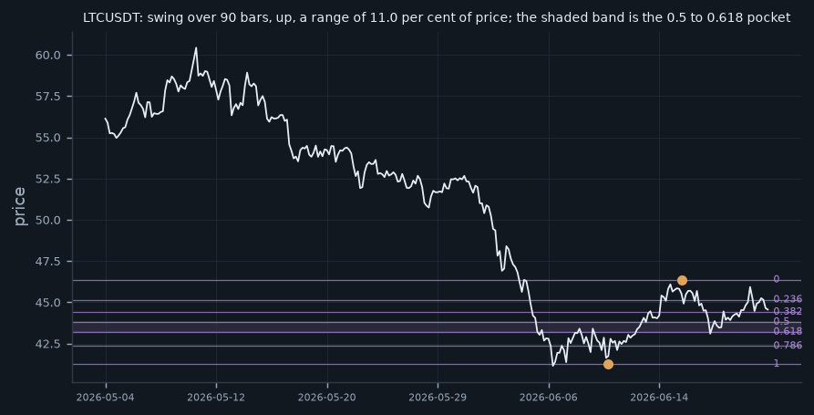

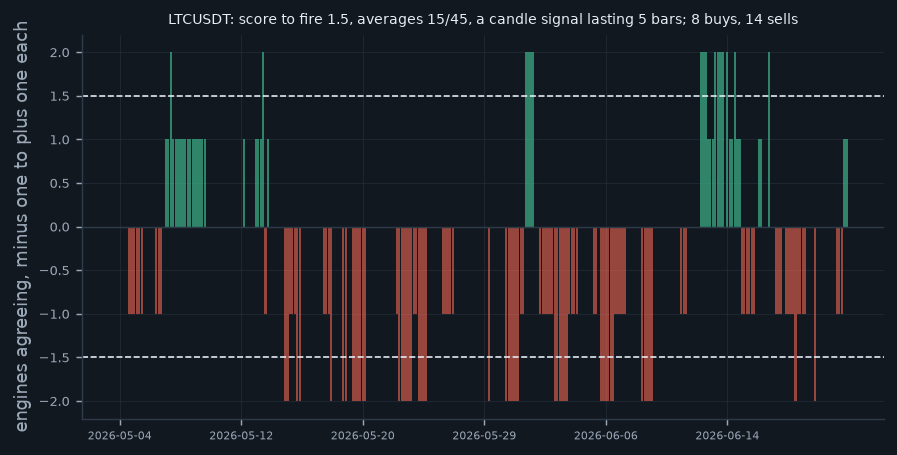

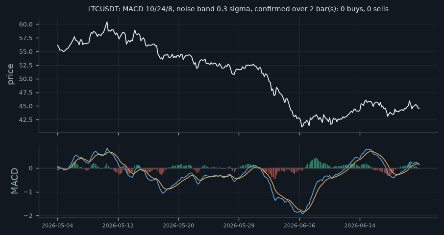

[1 more figures not shown]

4/22

Columns per feature family

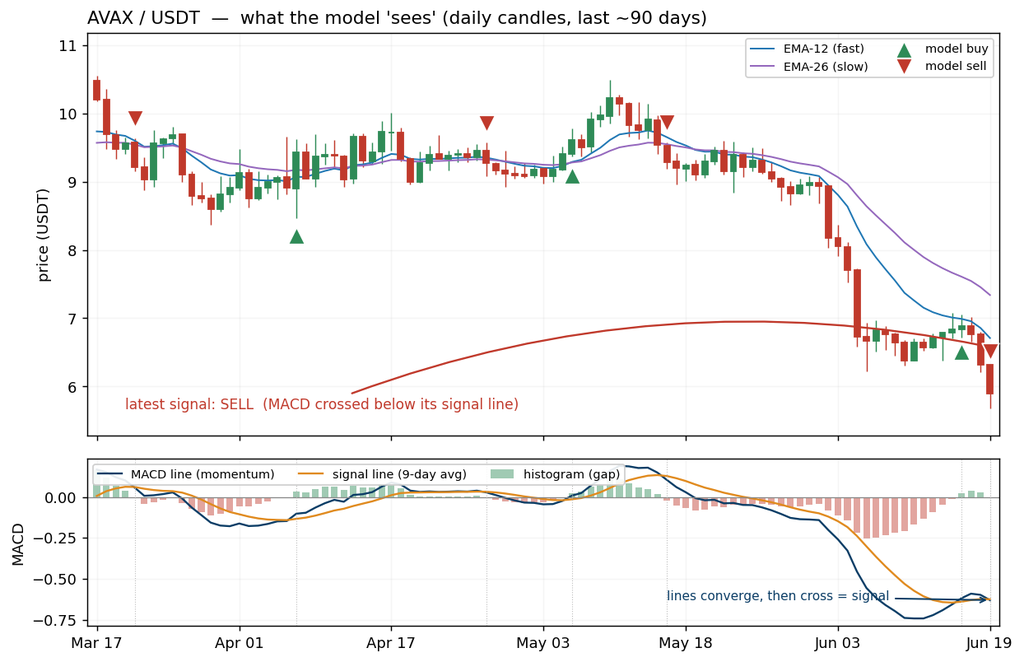

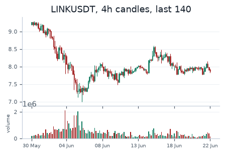

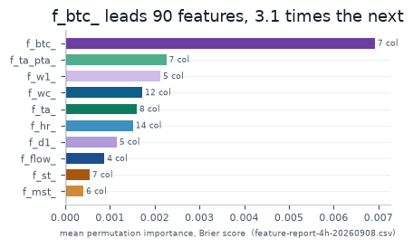

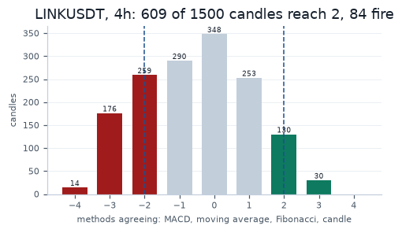

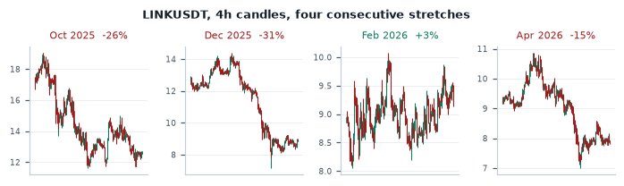

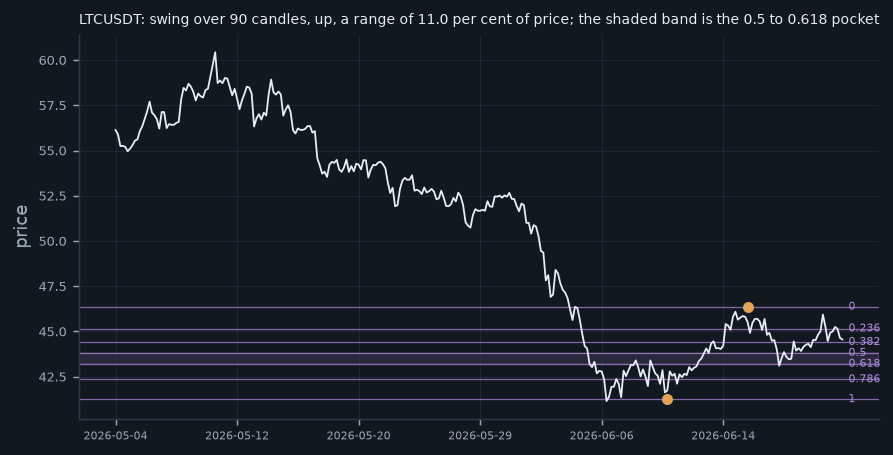

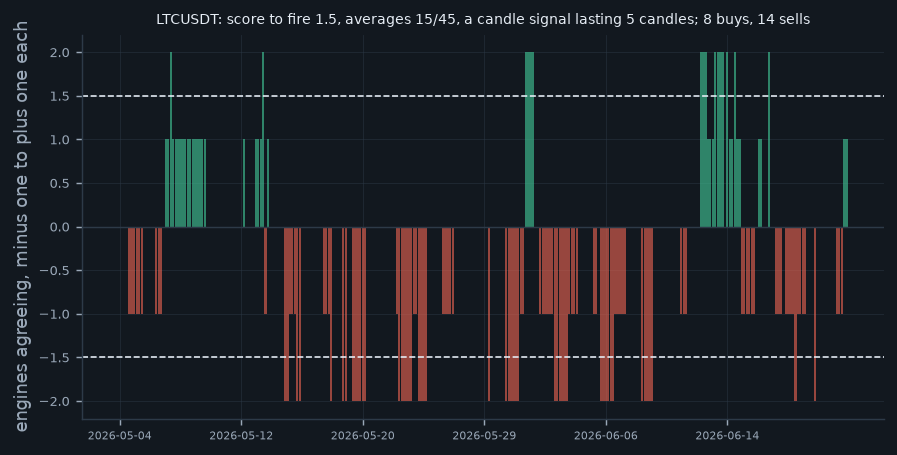

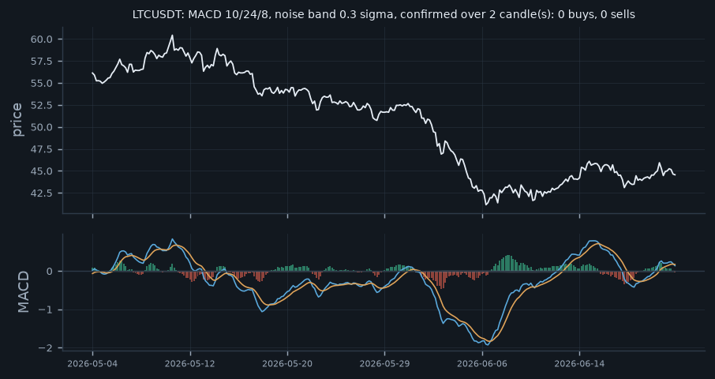

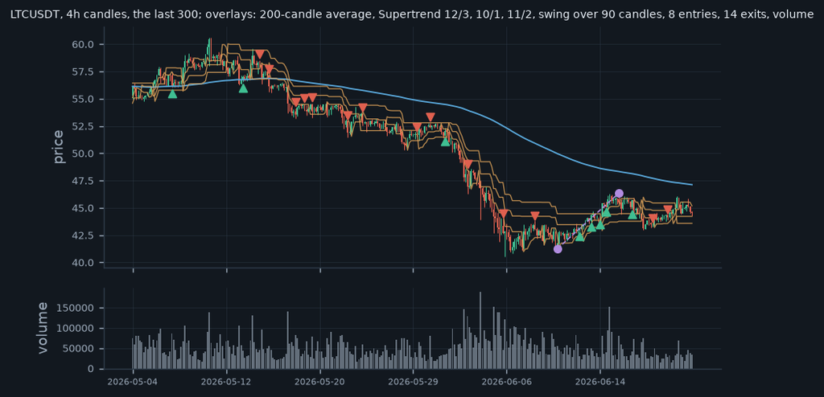

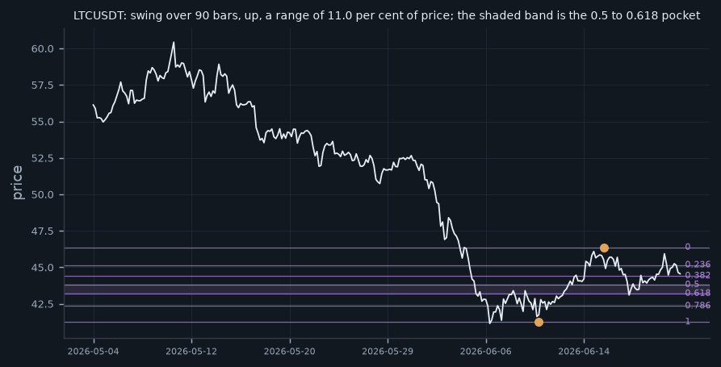

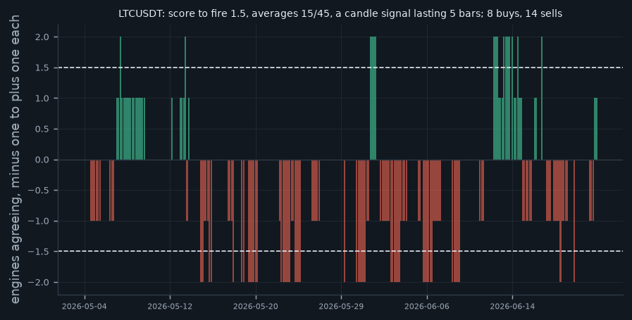

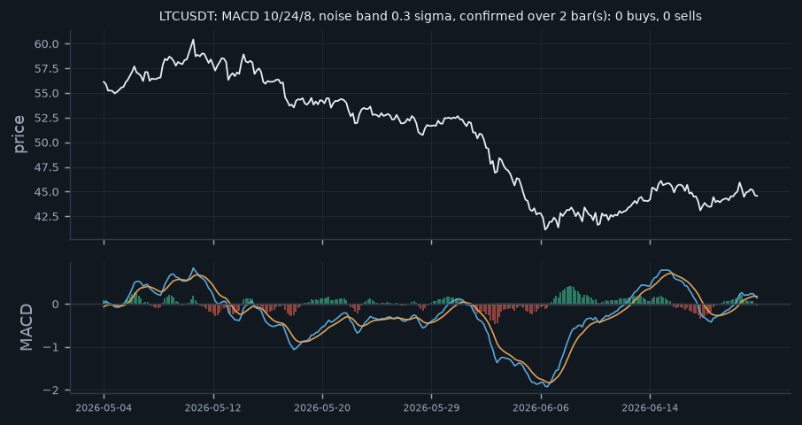

[1 more figures not shown]

5/22

Which families carry weight

Feature families and indicator engines.

08 Sep 2026 8 charts · settings

## B1Variablesscreen

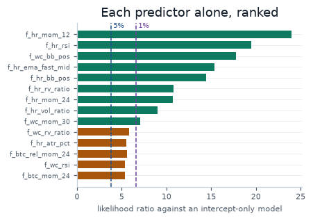

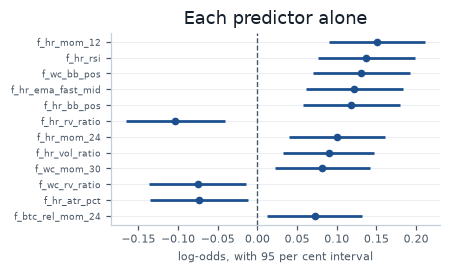

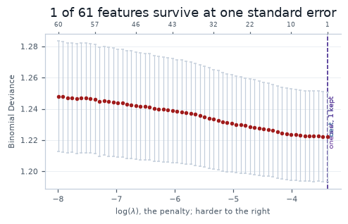

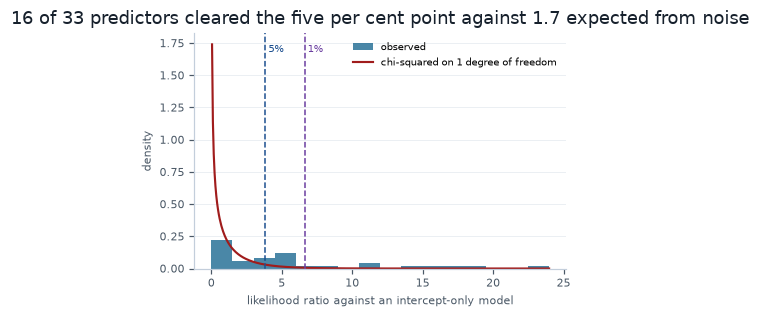

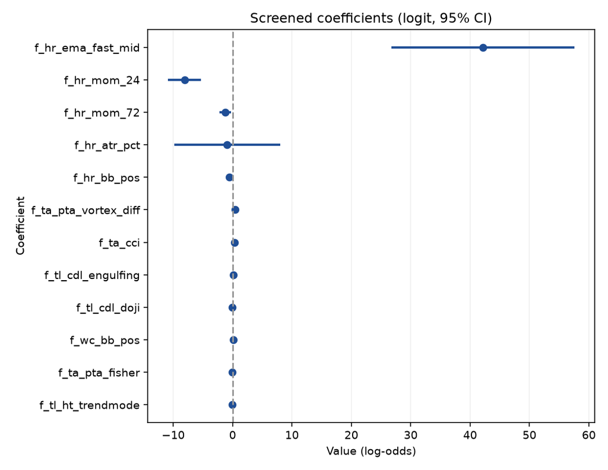

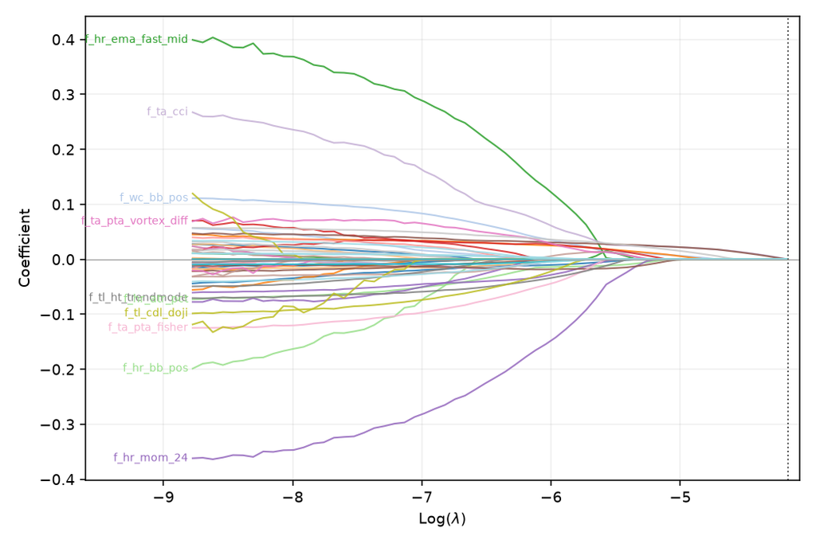

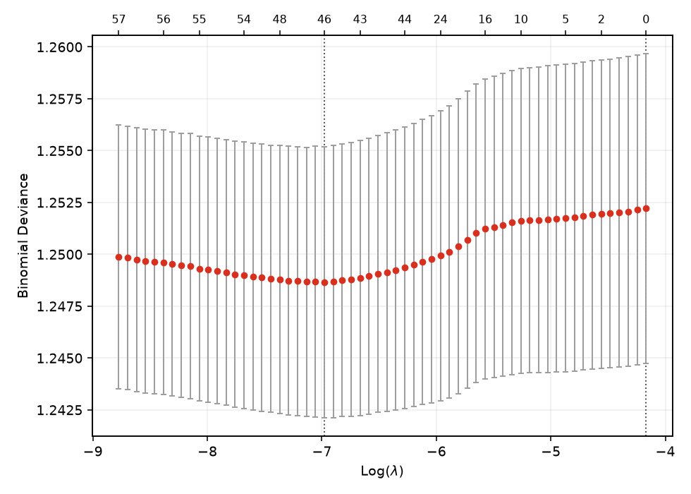

1/7

Each predictor alone, by likelihood ratio

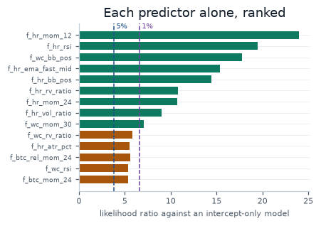

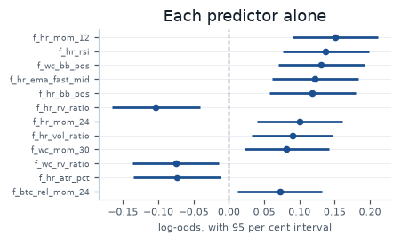

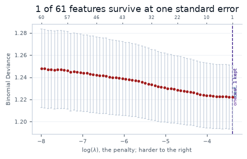

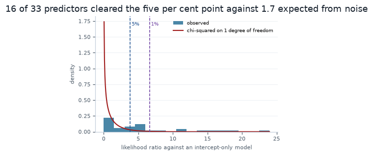

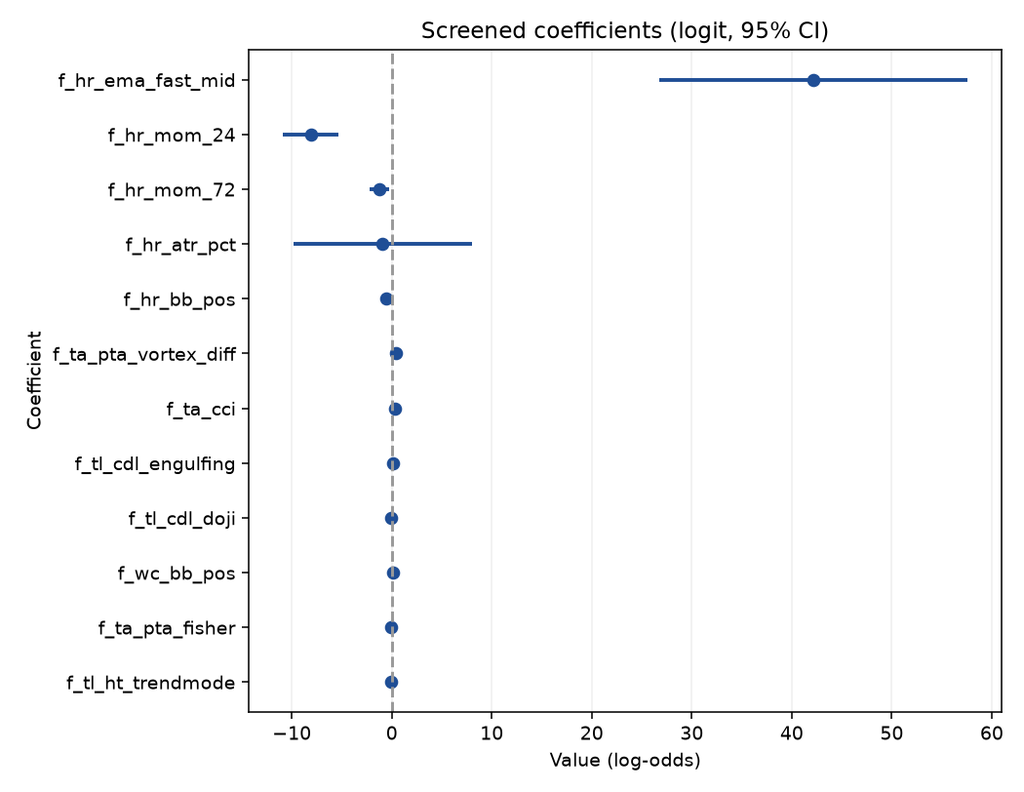

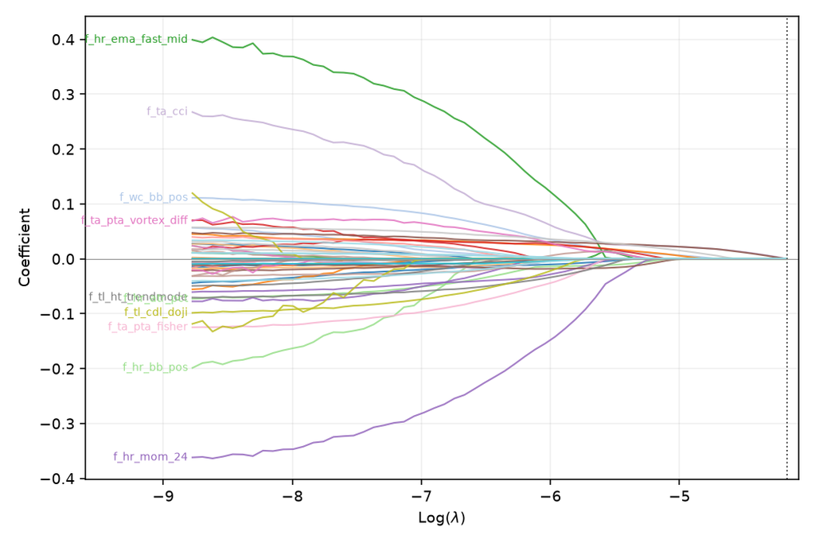

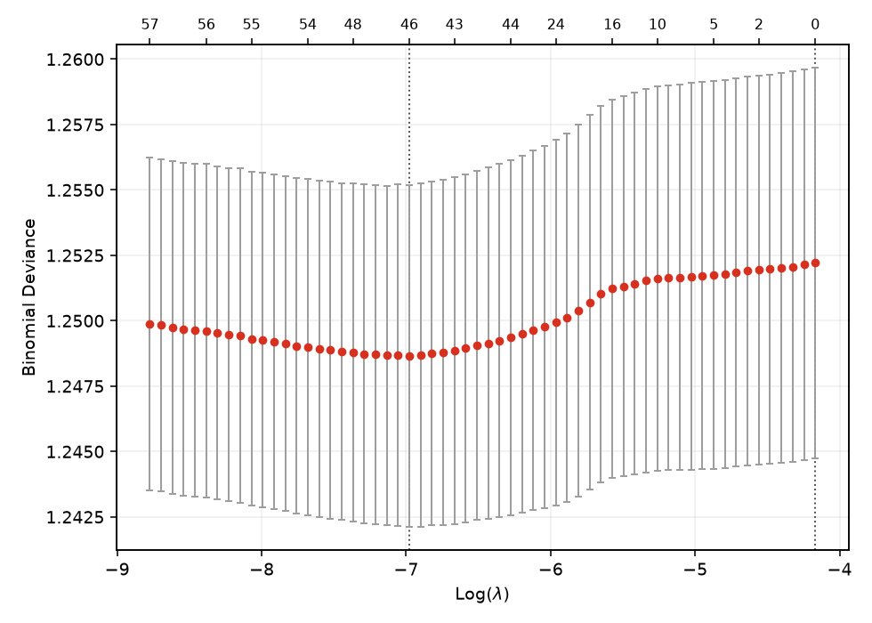

3/7

The elastic-net cross-validation curve

Univariate screen, elastic net, survivors.

22 Sep 2026 4 charts · settings